# PROJECT 2. INVESTIGATE A MOVIE DATASET

- Introduction
- Data Wrangling
- Exploratory Data Analysis
- Conclusions

## Introduction

For this project we had the opportunity to decide which dataset we wanted to analyse. I choose the 'TMDb movie data' because it is a topic of my interest. It has almost 11,000 films and it provides 19 characteristics and information about them, such as the budget and the popularity.

In this analysis the questions that will be answered are:

- Which are the most popular genres per year?
- What variables influence more the popularity of a movie?
- How has changed the duration of the movies over time?

## Data Wrangling

### General Properties

First of all the libraries needed for this analysis are imported.

```python
# Import the libraries
import pandas as pd
import numpy as np
import seaborn as sns
import matplotlib.pyplot as plt
%matplotlib inline
```

Then the csv that contains the dataset is loaded.

```python
# Import and read the csv
df = pd.read_csv('tmdb-movies.csv', sep=",")

# Print first rows to check everything has been imported correctly
df.head(2)
```

|  | id | imdb_id | popularity | budget | revenue | original_title | cast | homepage | director | tagline | ... | overview | runtime | genres | production_companies | release_date | vote_count | vote_average | release_year | budget_adj | revenue_adj |
| --- | --- | --- | --- | --- | --- | --- | --- | --- | --- | --- | --- | --- | --- | --- | --- | --- | --- | --- | --- | --- | --- |
| 0 | 135397 | tt0369610 | 32.985763 | 150000000 | 1513528810 | Jurassic World | Chris Pratt\|Bryce Dallas Howard\|Irrfan Khan\|Vi... | http://www.jurassicworld.com/ | Colin Trevorrow | The park is open. | ... | Twenty-two years after the events of Jurassic ... | 124 | Action\|Adventure\|Science Fiction\|Thriller | Universal Studios\|Amblin Entertainment\|Legenda... | 6/9/15 | 5562 | 6.5 | 2015 | 1.379999e+08 | 1.392446e+09 |
| 1 | 76341 | tt1392190 | 28.419936 | 150000000 | 378436354 | Mad Max: Fury Road | Tom Hardy\|Charlize Theron\|Hugh Keays-Byrne\|Nic... | http://www.madmaxmovie.com/ | George Miller | What a Lovely Day. | ... | An apocalyptic story set in the furthest reach... | 120 | Action\|Adventure\|Science Fiction\|Thriller | Village Roadshow Pictures\|Kennedy Miller Produ... | 5/13/15 | 6185 | 7.1 | 2015 | 1.379999e+08 | 3.481613e+08 |

2 rows × 21 columns

In the following steps the dataset is analysed to have a general idea of the size, statistics and NA values.

```python
# Know the size of the dataset
df.shape
```

```
(10866, 21)
```

```python
# Investigate the statistics
df.describe()
```

|  | id | popularity | budget | revenue | runtime | vote_count | vote_average | release_year | budget_adj | revenue_adj |
| --- | --- | --- | --- | --- | --- | --- | --- | --- | --- | --- |
| count | 10866.000000 | 10866.000000 | 1.086600e+04 | 1.086600e+04 | 10866.000000 | 10866.000000 | 10866.000000 | 10866.000000 | 1.086600e+04 | 1.086600e+04 |
| mean | 66064.177434 | 0.646441 | 1.462570e+07 | 3.982332e+07 | 102.070863 | 217.389748 | 5.974922 | 2001.322658 | 1.755104e+07 | 5.136436e+07 |
| std | 92130.136561 | 1.000185 | 3.091321e+07 | 1.170035e+08 | 31.381405 | 575.619058 | 0.935142 | 12.812941 | 3.430616e+07 | 1.446325e+08 |
| min | 5.000000 | 0.000065 | 0.000000e+00 | 0.000000e+00 | 0.000000 | 10.000000 | 1.500000 | 1960.000000 | 0.000000e+00 | 0.000000e+00 |
| 25% | 10596.250000 | 0.207583 | 0.000000e+00 | 0.000000e+00 | 90.000000 | 17.000000 | 5.400000 | 1995.000000 | 0.000000e+00 | 0.000000e+00 |
| 50% | 20669.000000 | 0.383856 | 0.000000e+00 | 0.000000e+00 | 99.000000 | 38.000000 | 6.000000 | 2006.000000 | 0.000000e+00 | 0.000000e+00 |
| 75% | 75610.000000 | 0.713817 | 1.500000e+07 | 2.400000e+07 | 111.000000 | 145.750000 | 6.600000 | 2011.000000 | 2.085325e+07 | 3.369710e+07 |
| max | 417859.000000 | 32.985763 | 4.250000e+08 | 2.781506e+09 | 900.000000 | 9767.000000 | 9.200000 | 2015.000000 | 4.250000e+08 | 2.827124e+09 |

```python
# Check datatypes and NA values
df.info()
```

```
<class 'pandas.core.frame.DataFrame'>
RangeIndex: 10866 entries, 0 to 10865
Data columns (total 21 columns):
id                      10866 non-null int64
imdb_id                 10856 non-null object
popularity              10866 non-null float64
budget                  10866 non-null int64
revenue                 10866 non-null int64
original_title          10866 non-null object
cast                    10790 non-null object
homepage                2936 non-null object
director                10822 non-null object
tagline                 8042 non-null object
keywords                9373 non-null object
overview                10862 non-null object
runtime                 10866 non-null int64
genres                  10843 non-null object
production_companies    9836 non-null object
release_date            10866 non-null object
vote_count              10866 non-null int64
vote_average            10866 non-null float64
release_year            10866 non-null int64
budget_adj              10866 non-null float64
revenue_adj             10866 non-null float64
dtypes: float64(4), int64(6), object(11)
memory usage: 1.7+ MB
```

From the 21 columns only 12 do not have missing values. In some cases, like for instance the *homepage*, it is not relevant for the analysis to have missing values in these columns. In the next section the data will be cleaned by imputing these missing values or deleting the rows that are not needed.

### Data Cleaning

In this step the dataset will be prepared for starting the EDA (Exploratory Data Analysis). First, the columns that are not relevant for the analysis are removed.

```python
# Delete not relevant columns
df.drop(['id', 'imdb_id', 'homepage', 'tagline', 'overview', 'cast', 'director', 'keywords', 'production_companies'], axis=1, inplace=True)

# Check the 9 columns have been dropped
df.head()
```

|  | popularity | budget | revenue | original_title | runtime | genres | release_date | vote_count | vote_average | release_year | budget_adj | revenue_adj |
| --- | --- | --- | --- | --- | --- | --- | --- | --- | --- | --- | --- | --- |
| 0 | 32.985763 | 150000000 | 1513528810 | Jurassic World | 124 | Action\|Adventure\|Science Fiction\|Thriller | 6/9/15 | 5562 | 6.5 | 2015 | 1.379999e+08 | 1.392446e+09 |
| 1 | 28.419936 | 150000000 | 378436354 | Mad Max: Fury Road | 120 | Action\|Adventure\|Science Fiction\|Thriller | 5/13/15 | 6185 | 7.1 | 2015 | 1.379999e+08 | 3.481613e+08 |
| 2 | 13.112507 | 110000000 | 295238201 | Insurgent | 119 | Adventure\|Science Fiction\|Thriller | 3/18/15 | 2480 | 6.3 | 2015 | 1.012000e+08 | 2.716190e+08 |
| 3 | 11.173104 | 200000000 | 2068178225 | Star Wars: The Force Awakens | 136 | Action\|Adventure\|Science Fiction\|Fantasy | 12/15/15 | 5292 | 7.5 | 2015 | 1.839999e+08 | 1.902723e+09 |
| 4 | 9.335014 | 190000000 | 1506249360 | Furious 7 | 137 | Action\|Crime\|Thriller | 4/1/15 | 2947 | 7.3 | 2015 | 1.747999e+08 | 1.385749e+09 |

From the table above it can be seen that in the column *genres* there is a vertical bar that separates the different geners of a movie. To make easier the further analysis, only the first genre, the principal one, will be keept (and the rest will be deleted).

```python
# Divide the genres in different colums and keep the first one
df['genres'] = df['genres'].str.split('|', expand=True)[0]

# An other option of doing the same with a function would be the following
# def get_first_genre(genres):
#    first_genre = genres.str.split('|', expand=True)[0]
#    return(first_genre)
# df['genres'] = get_first_genre(df['genres'])

# Check that has been done right
df.head(3)
```

|  | popularity | budget | revenue | original_title | runtime | genres | release_date | vote_count | vote_average | release_year | budget_adj | revenue_adj |
| --- | --- | --- | --- | --- | --- | --- | --- | --- | --- | --- | --- | --- |
| 0 | 32.985763 | 150000000 | 1513528810 | Jurassic World | 124 | Action | 6/9/15 | 5562 | 6.5 | 2015 | 1.379999e+08 | 1.392446e+09 |
| 1 | 28.419936 | 150000000 | 378436354 | Mad Max: Fury Road | 120 | Action | 5/13/15 | 6185 | 7.1 | 2015 | 1.379999e+08 | 3.481613e+08 |
| 2 | 13.112507 | 110000000 | 295238201 | Insurgent | 119 | Adventure | 3/18/15 | 2480 | 6.3 | 2015 | 1.012000e+08 | 2.716190e+08 |

Then the rows with NA are deleted.

```python
# Print the shape before the elimination
print(df.shape)

# Drop columns with NA
df.dropna(inplace=True)

# Check the new shape
print(df.shape)
```

```
(10866, 12)
(10843, 12)
```

It can be seen that 23 rows have been deleted because they contained NA values. The next step is be to check if there is data duplicated and delete it.

```python
# Check duplicated rows
sum(df.duplicated())
```

```
1
```

```python
# Delete the duplicated row
df.drop_duplicates(inplace=True)

#Check it worked
sum(df.duplicated())
```

```
0
```

Now the dataset should be ready for EDA, but let's check, just in case, the number of values and the datatype of the columns.

```python
df.info()
```

```
<class 'pandas.core.frame.DataFrame'>
Int64Index: 10842 entries, 0 to 10865
Data columns (total 12 columns):
popularity        10842 non-null float64
budget            10842 non-null int64
revenue           10842 non-null int64
original_title    10842 non-null object
runtime           10842 non-null int64
genres            10842 non-null object
release_date      10842 non-null object
vote_count        10842 non-null int64
vote_average      10842 non-null float64
release_year      10842 non-null int64
budget_adj        10842 non-null float64
revenue_adj       10842 non-null float64
dtypes: float64(4), int64(5), object(3)
memory usage: 1.1+ MB
```

## Exploratory Data Analysis

### Q1. Which are the most popular genres per year?

In order to answer this questions the columns that are needed are: *popularity*, *genres* and *release_year*. The first step is to create a new a dataframe with these columns based on the popularity of each genre per year.

```python
# Create a new dataframe
genre_popu = df[['release_year','genres', 'popularity']].groupby(['release_year','genres'], as_index=False).sum()

# Show it
genre_popu.head(10)
```

|  | release_year | genres | popularity |
| --- | --- | --- | --- |
| 0 | 1960 | Action | 4.725796 |
| 1 | 1960 | Adventure | 0.609985 |
| 2 | 1960 | Comedy | 2.744472 |
| 3 | 1960 | Crime | 0.269428 |
| 4 | 1960 | Drama | 3.437874 |
| 5 | 1960 | Horror | 1.529785 |
| 6 | 1960 | Thriller | 1.368494 |
| 7 | 1961 | Action | 1.622711 |
| 8 | 1961 | Adventure | 2.789192 |
| 9 | 1961 | Comedy | 3.453602 |

Then the dataframe needs to be grouped by the movie genre that was more popular per year. This is done in two steps. In the first one a new dataframe is created to group the maximimum popularity of a certain genre per year. In the next step this new dataframe is merge, using inner, to get the genre that got the maximum popularity for a certain year.

```python
# Select the maximum popularity per year
max_popu = genre_popu[['release_year', 'popularity']].groupby(['release_year'], as_index=False).max()

# Check it
max_popu.head(5)
```

|  | release_year | popularity |
| --- | --- | --- |
| 0 | 1960 | 4.725796 |
| 1 | 1961 | 3.453602 |
| 2 | 1962 | 5.134524 |
| 3 | 1963 | 4.539839 |
| 4 | 1964 | 4.906476 |

```python
# Select the genre most popular per year
genre_max_popu = pd.merge(genre_popu, max_popu, how='inner', on=['release_year', 'popularity'])

# Check it
genre_max_popu.head(10)
```

|  | release_year | genres | popularity |
| --- | --- | --- | --- |
| 0 | 1960 | Action | 4.725796 |
| 1 | 1961 | Comedy | 3.453602 |
| 2 | 1962 | Adventure | 5.134524 |
| 3 | 1963 | Comedy | 4.539839 |
| 4 | 1964 | Drama | 4.906476 |
| 5 | 1965 | Drama | 4.101663 |
| 6 | 1966 | Drama | 3.061122 |
| 7 | 1967 | Comedy | 4.712062 |
| 8 | 1968 | Science Fiction | 4.176388 |
| 9 | 1969 | Action | 2.942058 |

Now the dataset is ready to be visualized. This two webpages ([link1](https://stackoverflow.com/questions/48958035/pandas-convert-some-rows-to-columns-in-python) and [link2](https://pandas.pydata.org/pandas-docs/version/0.15.0/visualization.html)) were checked to make this stacked bar plot.

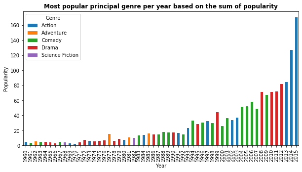

```python
genre_max_popu.rename(columns = {'genres': 'Genre'})\
.pivot(index='release_year', columns='Genre', values='popularity').reset_index()\
.plot(kind='bar',x='release_year', stacked=True, figsize=(10,5));
plt.xlabel("Year");
plt.ylabel("Popularity");
plt.title("Most popular principal genre per year based on the sum of popularity", weight='bold');
plt.show();
```

It can be seen in the graph that the most popular genres in the last 15 years are action, drama and comedy. Let's look at the numbers of each genre.

```python
# Count the number of years each genre was more popular
genre_max_popu['genres'].value_counts()
```

```
Comedy             18
Drama              18
Action             14
Adventure           4
Science Fiction     2
Name: genres, dtype: int64
```

```python
# Search the number of genres
genre_popu['genres'].nunique()
```

```
20
```

From 1960 to 2015 the most popular pincipal genres have been comedy and drama, followed by action. Moreover, in some years adventure and science fiction movies were also very popular. The rest of the 15 genres, like horror or thriller, are not that popular.

### Q2. What variables influence more the popularity of a movie?

Frist let's plot a general graph to see which variables are more correlated with popularity.

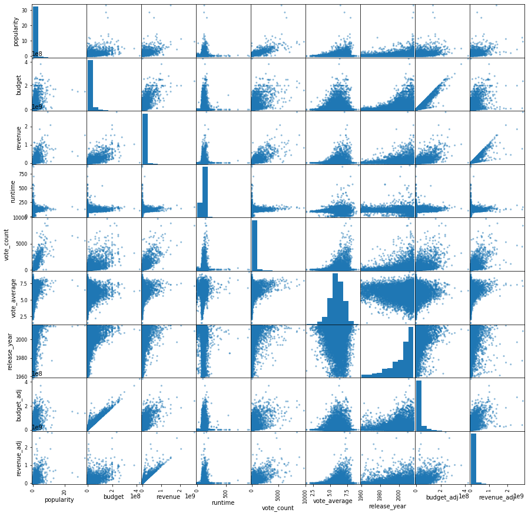

```python
pd.plotting.scatter_matrix(df, figsize=(15, 15));
```

From the graph above it can be seen that the popularity of a movie is correlated with the *budget*, the *revenue* and the *vote_count*. The next step will be to plot a correlation matrix and see the correlation represented with numbers (this [link](https://seaborn.pydata.org/generated/seaborn.heatmap.html) was useful).

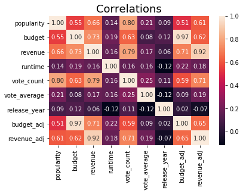

```python
# Create correlation matrix
sns.heatmap(df.corr(), annot=True, fmt=".2f")
plt.title('Correlations', fontsize=18)
plt.show()
```

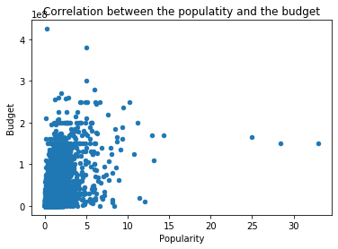

```python
# Create a scatterplot
df.plot(x='popularity', y='budget', kind='scatter')
plt.title('Correlation between the populatity and the budget')
plt.xlabel('Popularity')
plt.ylabel('Budget');
```

### Q3. How has changed the duration of the movies over time?

In this last question it is only necessary to work with two columns: *runtime* and *release_year*.

```python
# Create a new dataframe
duration =  df[['release_year', 'runtime']].groupby(['release_year'], as_index=False).mean()

# Show it
duration.head(5)
```

|  | release_year | runtime |
| --- | --- | --- |
| 0 | 1960 | 110.656250 |
| 1 | 1961 | 119.419355 |
| 2 | 1962 | 124.343750 |
| 3 | 1963 | 111.323529 |
| 4 | 1964 | 109.214286 |

Once the new dataset is created, the only missing part is visualizing the results.

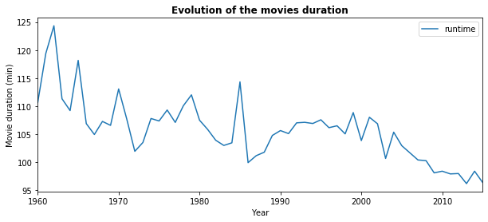

```python
# Create plot
duration.plot(x='release_year', y='runtime', figsize=(10, 4))
plt.title('Evolution of the movies duration', weight='bold')
plt.ylabel('Movie duration (min)')
plt.xlabel('Year');
```

The lines are not very smooth because they differ a lot between years. For that reason a moving average is calculated after checking this [link](https://pandas.pydata.org/pandas-docs/version/0.23.4/generated/pandas.DataFrame.rolling.html).

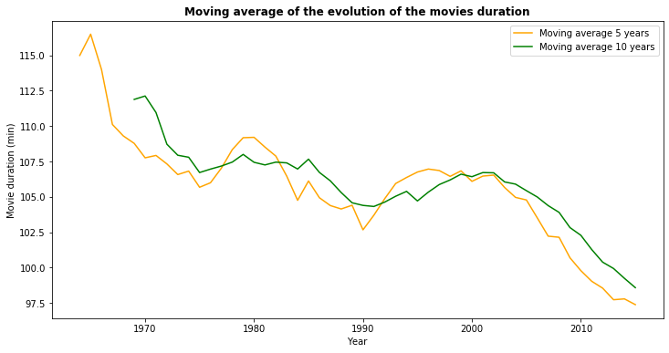

```python
# Create two moving averages
duration_ma_5 = duration.runtime.rolling(window=5).mean()
duration_ma_10 = duration.runtime.rolling(window=10).mean()

# Plot the results
plt.figure(figsize=(12, 6))
plt.plot(duration.release_year, duration_ma_5, label='Moving average 5 years', color='orange')
plt.plot(duration.release_year, duration_ma_10, label='Moving average 10 years', color='green')
plt.title('Moving average of the evolution of the movies duration', weight='bold')
plt.ylabel('Movie duration (min)')
plt.xlabel('Year')
plt.legend(loc='upper right')
plt.show();
```

With the previous graph it is clear the general tendency of the duration of the movies to decrease over time.

## Conclusions

#### Q2. What variables influence more the popularity of a movie?

- The popularity of a movie is positive correlated with the budget, revenue and vote_count.
- Although revenue and vote_count have higher correlations than the budget, these other parameters are linked with the popularity. Budget is an independent variable with popularity, and it seems that more expensive movies have then higher popularity.

#### Q3. How has changed the duration of the movies over time?

- The average movie duration has changed a lot per year.
- The general tendency is that movies have a lower duration over time.

## Limitations

#### Q1.

The classification of the most popular movie genres was done based on the principal genre, and the rest of the genres that had a certain movie were not taken into account. The results migh have been different if all the genres would have been analysed.

#### Q2.

There is no information about how the popularity of the movie is calculated, which made me assume in the data analysis that it was related with the revenue and the vote_count in a certain way. It does not make sense to compare two variables that are dependent and that is the reason why at the end only the budget was compared with the popularity. A better description of the variables would be needed to understand the correlation between them.

#### Q3.

The duration of the movies decrease over time for this dataset, which does not include all the films in the world, so might not be representativefor all the movies. This can be apply to all the analsis and variables.